# Konicek_homework_3

kelli

2025-02-04

## Libraries

```r
library(here)
library(tidyverse)
library(car)
library(ggResidpanel)
library(ggeffects)
library(effects)
library(performance)
```

## Data

```r
raw <- read_csv(here("week_3", "data", "CRCP_Reef_Fish_Surveys_Hawaii_expanded_posted.csv"))
```

## 1)

*Identify the top twelve species in terms of these three statistics: (1) mean abundance, (2) maximum abundance, (3) standard deviation of abundance.*

```r
#get all stats for all species
abundances <- raw %>%
  select(c(commonname,count))%>%
  group_by(commonname)%>%
  summarise(mean = (mean(count, na.rm = TRUE)),
            max = (max(count, na.rm = TRUE)),
            sd = (sd(count, na.rm=TRUE)))

#Make tables with top twelve so it's easier to look at knitted
avg.abundance <- top_n(abundances, 12, mean)%>%
  select(commonname, mean)%>%
  arrange(desc(mean))
max.abundance <- top_n(abundances, 12, max) %>%
  select(commonname,max)%>%
  arrange(desc(max))
deviance <- top_n(abundances, 12, sd) %>%
  select(commonname,sd)%>%
  arrange(desc(sd))

avg.abundance
```

```
## # A tibble: 12 × 2
##    commonname                 mean
##    <chr>                     <dbl>
##  1 Vanderbilt's chromis      30.4
##  2 Agile chromis             19.0
##  3 Brown surgeonfish          6.22
##  4 Spotted surgeonfish        6.11
##  5 Yellow tang                5.03
##  6 Common bluestripe snapper  4.87
##  7 Arc-eye hawkfish           2.95
##  8 Hawaiian bicolor chromis   2.56
##  9 Whitebar surgeonfish       2.47
## 10 Saddle wrasse              2.32
## 11 Mackerel scad              1.84
## 12 Striated wrasse            1.84
```

```r
max.abundance
```

```
## # A tibble: 12 × 2
##    commonname                  max
##    <chr>                     <dbl>
##  1 Common bluestripe snapper   600
##  2 Agile chromis               500
##  3 Vanderbilt's chromis        500
##  4 Hawaiian bicolor chromis    200
##  5 Delicate round herring      150
##  6 Hawaiian chromis            150
##  7 Mackerel scad               150
##  8 Striated wrasse             100
##  9 Threespot chromis           100
## 10 Yellowfin goatfish           90
## 11 Iridescent cardinalfish      86
## 12 Whitetail chromis            80
```

```r
deviance
```

```
## # A tibble: 12 × 2
##    commonname                   sd
##    <chr>                     <dbl>
##  1 Vanderbilt's chromis      52.7
##  2 Agile chromis             41.7
##  3 Common bluestripe snapper 31.5
##  4 Hawaiian bicolor chromis  10.6
##  5 Hawaiian chromis           9.45
##  6 Mackerel scad              9.36
##  7 Delicate round herring     7.96
##  8 Spotted surgeonfish        6.47
##  9 Yellow tang                6.00
## 10 Brown surgeonfish          5.99
## 11 Striated wrasse            5.92
## 12 Shoulderbar soldierfish    4.92
```

## 2)

*Using the top twelve species based on mean abundance, plot a scatterplot of count vs. depth.*

*First way to make this plot, using for loops:*

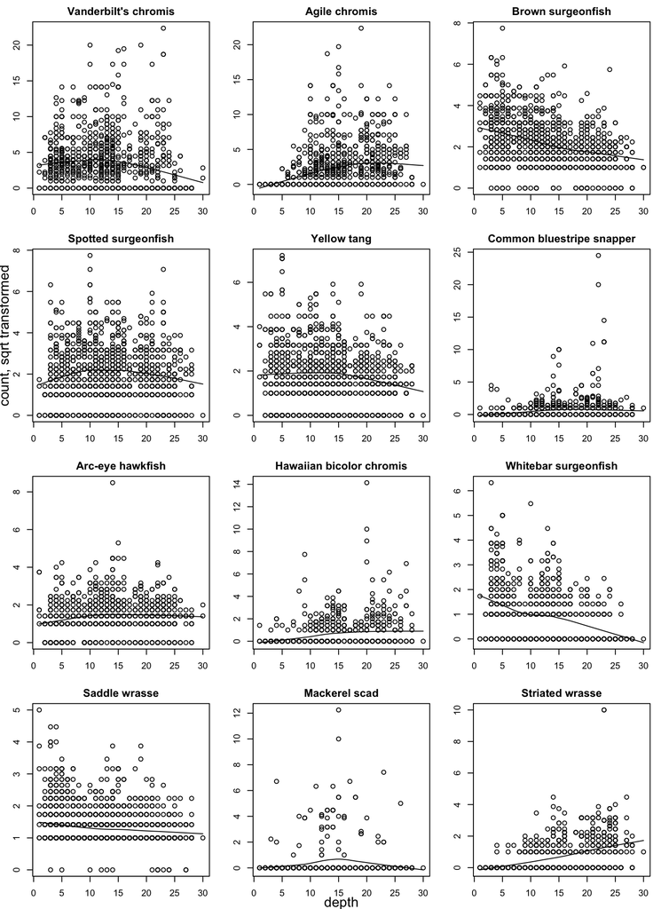

```r
toptwelve <- as.factor(avg.abundance$commonname)
raw$commonname <-as.character(raw$commonname)

par(mfrow = c(4,3), mar= c(3,3,2,1))

for(i in 1:12) {
species.data <- subset(raw, commonname == toptwelve[i])

countsq <- sqrt(species.data$count)
ymax = max((species.data$count))
xmax = max(species.data$depth)

with(species.data,scatter.smooth(depth, countsq, main = toptwelve[i]))
# Add x-axis and y-axis labels only on the outermost plots
  if (i == 11) {  # bottom-left panel
    mtext("depth", side = 1, line = 2)  # add x-axis label (bottom panel)
  }
  if (i == 4) {  # top-left panel
    mtext("count, sqrt transformed", side = 2, line = 2)  # add y-axis label (left panel)
  }
}
```

*Second, use ggplot() to do the same thing.*

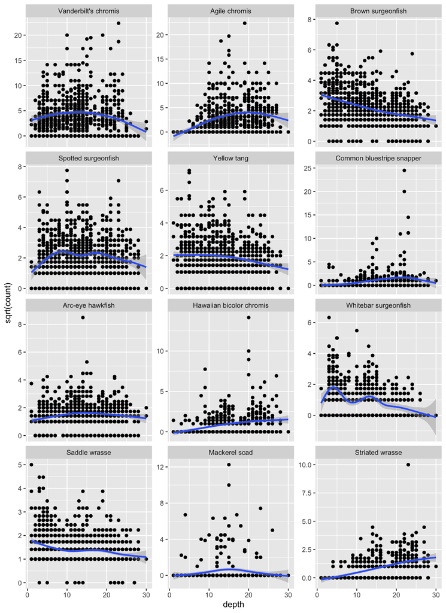

```r
toptwelveCh <- as.character(toptwelve)

fishes <- raw %>%
  filter(commonname %in% toptwelveCh)%>%
  select(commonname, count, depth)

fishes$commonname <- factor(fishes$commonname, levels = avg.abundance$commonname)

 fishplot<- ggplot(fishes, aes(x= depth, y= sqrt(count)))+
           geom_point()+
           geom_smooth()+
    facet_wrap(~commonname, ncol=3,scales = "free_y")
fishplot
```

This one is a little messy re: code.

*What are your conclusions from this visual inspection of the data?* WELL. From this visual inspection, it looks like you can find a more of certain species in different depths of the water column. For instance, it seems they found less brown surgeon fish as the water got deeper, but more Hawaiian bicolor chromis and striated wrasse. It looks like there might be several different kinds of distributions.

## 3)

*Make a new plot that shows abundance vs. depth for the top 5 species, including smoothers, but this time put all of the species on the same scatterplot and distinguish them with different colors.*

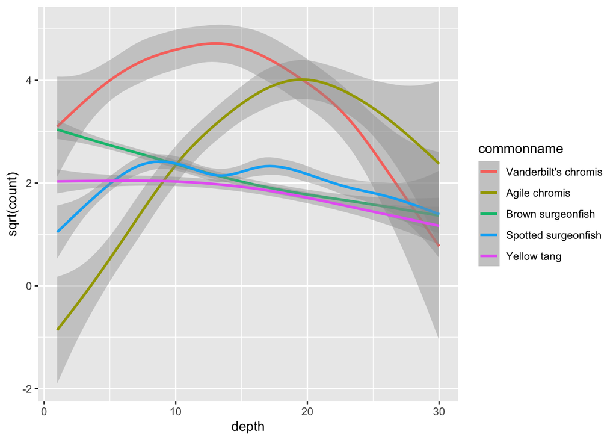

```r
plot <- fishes %>%
  filter(as.integer(commonname)<6)%>%
  ggplot(aes(x=depth, y= sqrt(count), color= commonname))+
                 geom_smooth()
plot
```

*What is your interpretation of this plot?.*

Seems like these species have different depth niches because their distributions are different. With the scatterplot was too messy for me, but just the smoothed lines makes it seem that these species don’t follow the same water column distribution. Yellow Tang and Brown surgeonfish might be similar, but I think I would hypothesize that the two chromis species and the spotted surgeonfish occupy different niches.

*Fit a linear model that tests whether these 5 species have different depth niches. Based on residual diagnostic plots of this model, and a plot of the fitted effects, do you think a linear model is a good approach for testing this question? If not, why not?*

```r
lmdata <- fishes %>%
  filter(as.integer(commonname)<6)

model <- lm(count ~ commonname+depth, data = lmdata)
summary(model)
```

```
##
## Call:
## lm(formula = count ~ commonname + depth, data = lmdata)
##
## Residuals:
##    Min     1Q Median     3Q    Max
## -31.78  -5.69  -2.91   2.43 480.60
##
## Coefficients:
##                                Estimate Std. Error t value Pr(>|t|)
## (Intercept)                    29.31051    1.07801  27.190   <2e-16 ***
## commonnameAgile chromis       -11.58236    1.25080  -9.260   <2e-16 ***
## commonnameBrown surgeonfish   -24.18132    1.11468 -21.693   <2e-16 ***
## commonnameSpotted surgeonfish -24.38422    1.11337 -21.901   <2e-16 ***
## commonnameYellow tang         -25.45954    1.12651 -22.600   <2e-16 ***
## depth                           0.08814    0.05187   1.699   0.0893 .
## ---
## Signif. codes:  0 '***' 0.001 '**' 0.01 '*' 0.05 '.' 0.1 ' ' 1
##
## Residual standard error: 26.67 on 6098 degrees of freedom
## Multiple R-squared:  0.1091, Adjusted R-squared:  0.1084
## F-statistic: 149.3 on 5 and 6098 DF,  p-value: < 2.2e-16
```

```r
#F stat
Anova(model)
```

```
## Anova Table (Type II tests)
##
## Response: count
##             Sum Sq   Df  F value  Pr(>F)
## commonname  529653    4 186.1831 < 2e-16 ***
## depth         2054    1   2.8875 0.08932 .
## Residuals  4336890 6098
## ---
## Signif. codes:  0 '***' 0.001 '**' 0.01 '*' 0.05 '.' 0.1 ' ' 1
```

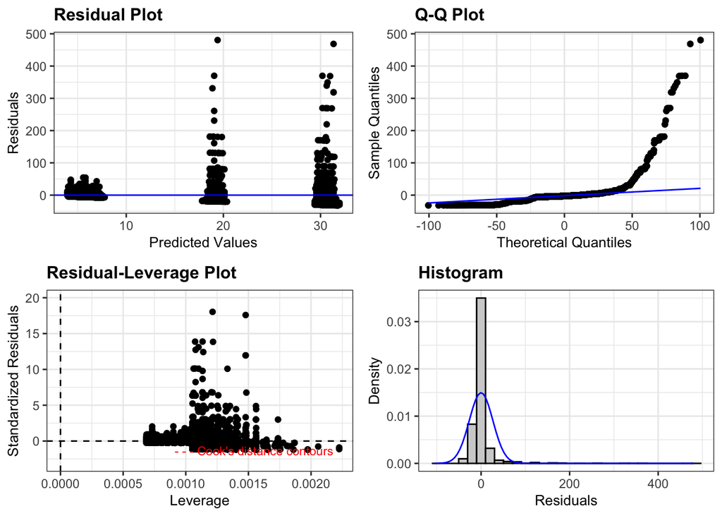

```r
resid_panel(model, plots = c('resid', 'qq', 'lev', 'hist'))
```

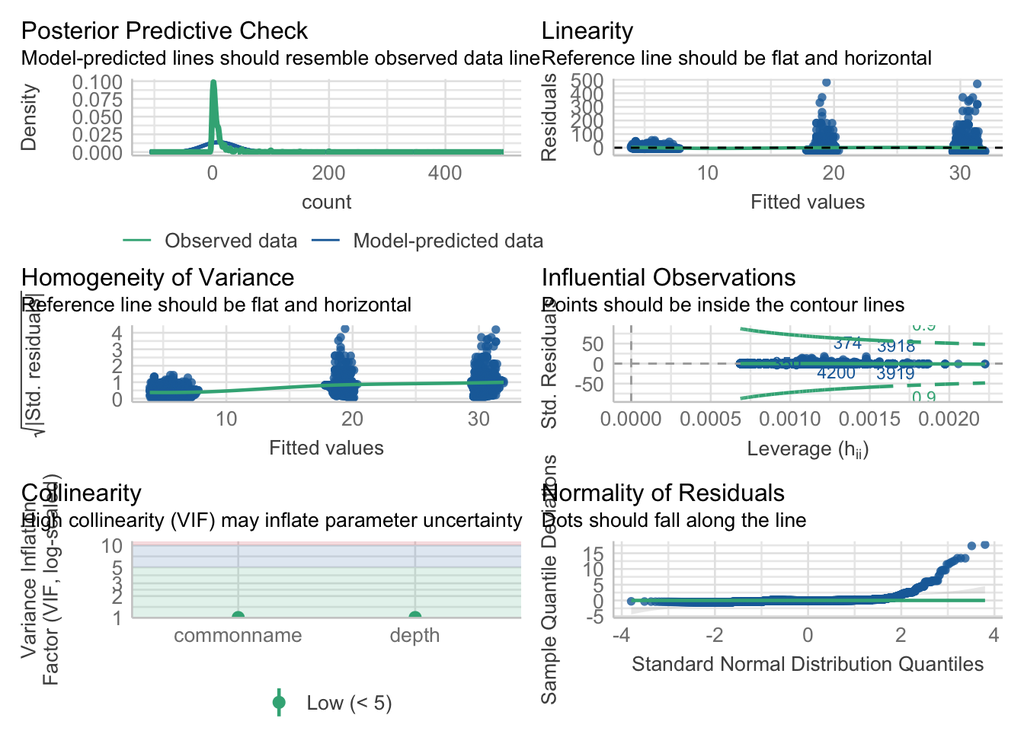

```r
check_model(model) #wanted to check with the dumb guy version of residual plots too
```

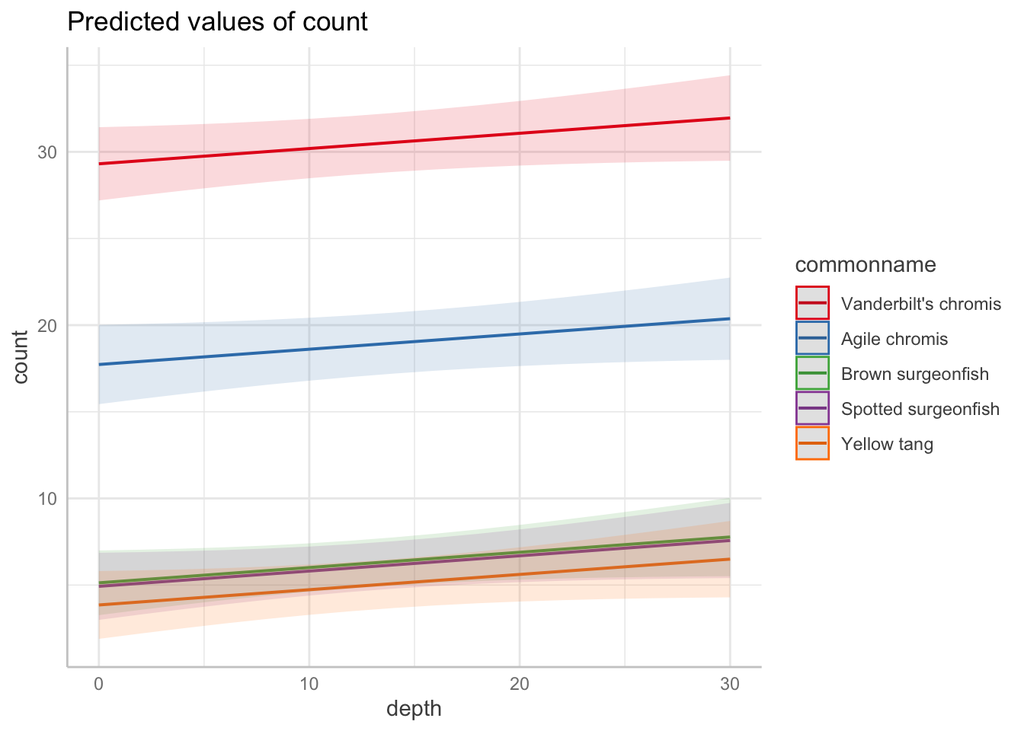

```r
plot(ggeffect(model, terms = c('depth','commonname')))
```

Especially for the residual plot and the Q-Q plots, the residuals look pretty skewed. For that reason, and because at least two of these species don’t even seem have a linear relationship to depth just based on looking at the raw data, I don’t think a linear model works for these.